# Introduction

## Do Neighborhoods Matter for Success?

## A Key Question:

1. Does geography (e.g. neighborhoods) actually nurture success (or failure)?… Or
   - Do certain locations just attract those who would succeed (or fail)?
- In Economics jargon: Is there a causal impact of geography on economic success?

## Chetty and Henderson (2016): Study Design

- Look at earnings records of five million families that moved with children over 17 year time-period
- Quasi-experimental design that relies on differences in the timing of when families move across areas.
  - Compare adulthood earnings by comparing families that moved from one city to another when their children were young versus older.
- Better than compare families in different areas
  - bias: because some families choose to live in certain areas

## Example

- Family A is poor and moves from Cincinnati to Pittsburgh when child is 5-years old
- Family B is poor makes same move, but child is 14-years old
- Look at adulthood earnings for the 5-year old and 14-year old

## Main Findings

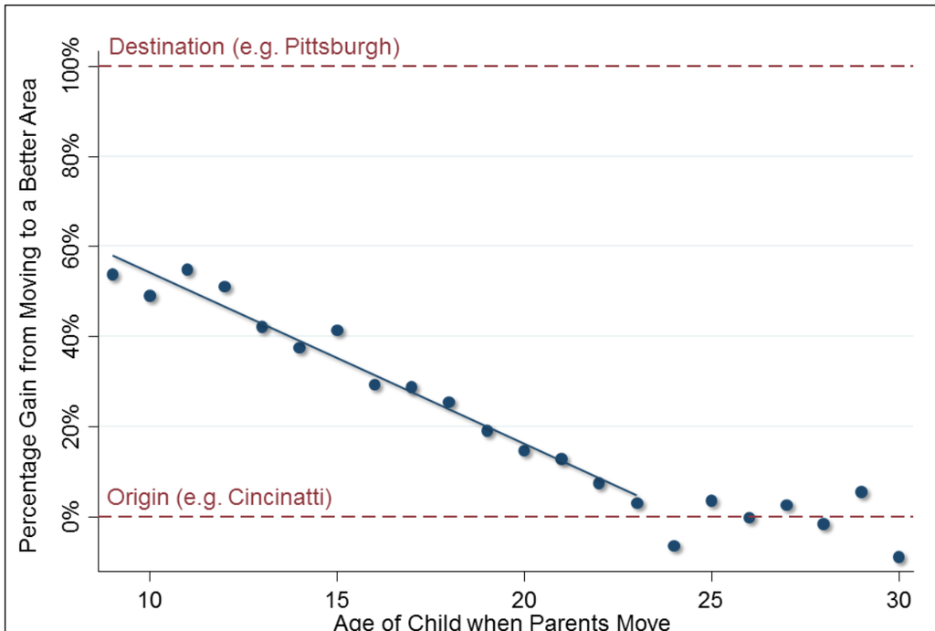

- Income at age 26 if from a poor family AND
  - Always lived in Cincinnati: $23,000
  - Always lived in Pittsburgh: $28,000
- For a set of families that moved from Cincinnati to Pittsburgh and the child is
  - 9 years old –> earn 50% of difference: $25,500
  - 23 years old –> relatively no gain relative to those who stayed in Cincinnati permanently

## County-Level Estimates of Causal Exposure Effects

- Can estimate the effect of spending an additional year of childhood in each county.

## Best 10 and Worst 10 places to Live

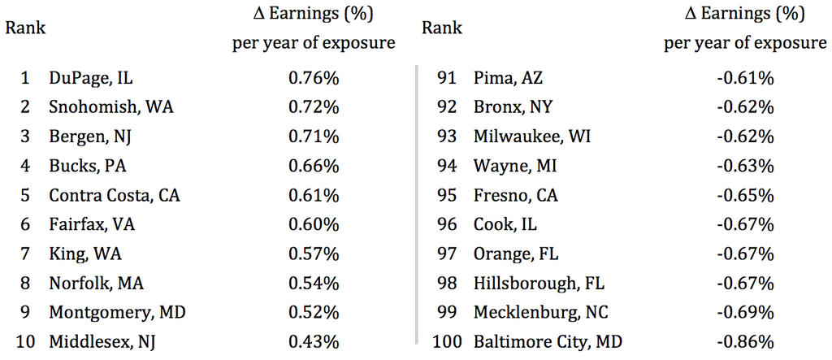

- DuPage:
  - 1 extra year of childhood raises household income in adulthood by 0.76%
  - Birth-20yrs: Raise a child’s earnings by 15% relative to the national average.
- Baltimore
  - 1 extra year of childhood reduces household income in adulthood by 0.86%
  - Birth-20yrs: Reduce a child’s earnings by 17% relative to the average.

## 2015 Baltimore Riots

- Does low chance for economic success help add perspective on understanding social protests against policy brutality?

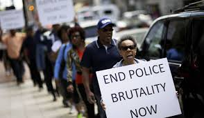

[figure not shown]

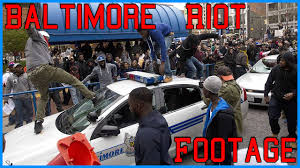

## Map Results

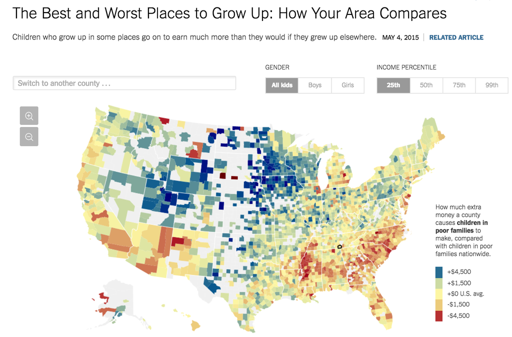

## Characteristics of Best Places to Live

- Elementary schools with higher test scores
- A higher share of two-parent families
- Greater levels of involvement in civic and religious groups
- More residential integration of affluent, middle-class and poor families

## Summary

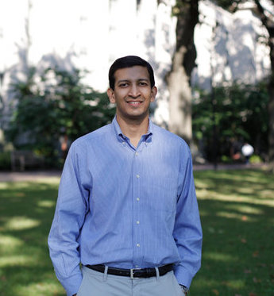

“The data shows we can do something about upward mobility…Every extra year of childhood spent in a better neighborhood seems to matter.” ~ Chetty, Harvard Economist

- The findings suggest that geography does not merely separate rich from poor but also plays a large role in determining which poor children achieve the so-called American dream.

## Policy Implications

1. To improve economic mobility, policy makers should focus on
   - improving childhood environments (e.g., by improving local schools)
   - not just on the strength of the local labor market or availability of jobs.

## Question to Consider

- We know geography matters for success
- Should government implement policies that encourage poorer households to migrate to richer areas?
  - i.e. Indirect place-based policy
  - What are some potential pros/cons?

Let’s look at an example!

## Moving to Opportunity: Mobility policy in US

## MTO

- Economic Experiment: 1994-1998 in five large U.S. cities.
- Approximately 4,600 families living in high-poverty areas
- Random Assignment into 3 groups based on lottery
  - MTO Voucher Experiment group: Required to move to area with < 10% poverty
  - Section 8 voucher: provided public housing, but no requirement to move
  - Control Group: No Voucher

## Backdrop

[video not shown]

## Backdrop Los Angeles

- Los Angeles, 1991 Race Riots

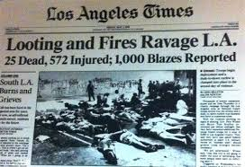

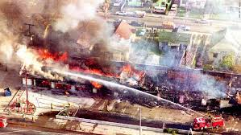

[figure not shown]

- Brought Awareness to Race, Neighborhoods and Urban Poverty
- Following Race riots, Congress created an anti-poverty experiment called *Moving to Opportunity (MTO)*.

## Initial MTO Program Results

- Disappointing
  - MTO Voucher no effect on the employment and earnings of parents,
  - some positive effects physical and mental health,
  - few notable effects on children.
- Led to conclusion that neighborhood environments are not an important component of economic success.

## A New Hypothesis and New Findings

- Initial studies too early, failed to take into account enough time to track effects on younger children that moved
- New hypothesis:
  - Years of exposure to a good neighborhood is what matters
  - Subsequent effects during adulthood to be different for toddlers who moved versus teenage
  - Toddlers enjoy more time in good neighborhood, benefit more.

## Chetty et al. (2016): Results

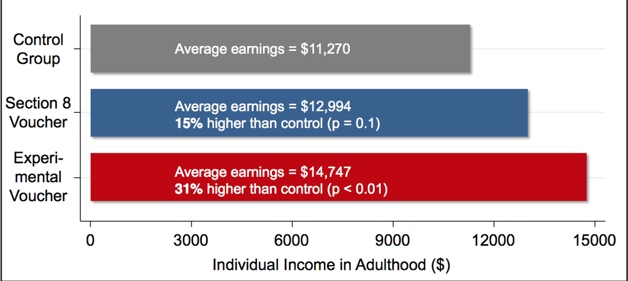

- The MTO experiment increased the earnings of children who moved to low-poverty areas before age 13 by 31%

## The Moving Age Matters!

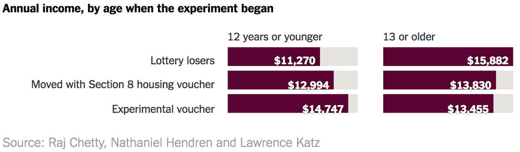

- 13+ who moved experienced lower adulthood income
- WHY is this?

## The Moving Age Matters!

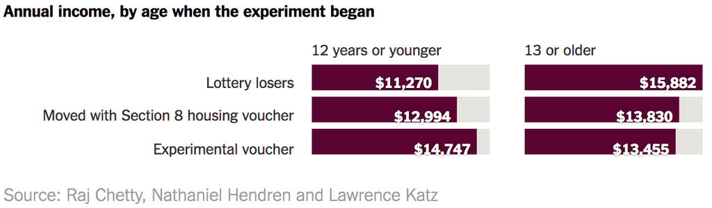

- 13+ who moved experienced lower adulthood income
- WHY is this?
  1. Disruptive move?
  2. Few benefits from spending only a short time in a better neighborhood?

## Long-Run Benefits of MTO Beyond Income

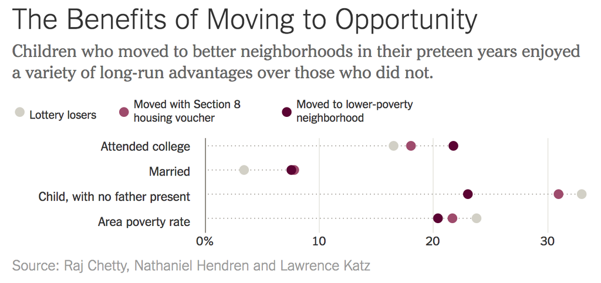

## Policy Implications?

1. New approach to housing policy
   - Reduce waiting times for parents of young children on waiting lists for housing vouchers
   - Current housing policy gives tax incentives to developers who build in poor neighborhoods
   - Instead, should reward developers who build affordable housing in areas that seem to offer better environments